# Raminski_UCB_R_Class_Asgt_7

Michael Raminski

Thursday, May 4, 2017

## Diary

For this assignment I used a database featuring the 2016 fantasy football statistics of the top 50 offensive players at each position.

Data Source: https://fantasydata.com/nfl-stats/nfl-fantasy-football-stats.aspx

Because of the smaller size of the data set, it is probably not ideal for linear regression, but I wanted to choose a data set that I was both interested in and had familiarity with.

I was very curious when reading section 8.2 of the book (page 177). It is made to seem that the definition of “linear regression” is very broad. Kabacoff says that this formula would still qualify as linear regression: Y~ log(X1) + sin(x2) This formula being considered linear regression is confusing to me, and the book doesn’t adequately describe (at least not adequately for me) how linear regression is actually defined.

Additionally, for the qqPlot, my graph did not seem to be interactive- when I placed my cursor over the plot points, I did not see any labels. Also, when I ran the qqPlot, I was able to produce a graph but the R console would always get stuck (it wouldn’t move on to an empty “>” just sat at the “+”).

## Summary of Results

### Task 1

For simple linear regression I tried to regress the Fantasy points per game at each position by individual predictor variables that don’t result directly in points. This gives the model a more predictive quality rather than looking at the association between points per game and the variables that produce those points.

For polynomial regression, I looked back at the scatterplots that I had created in the last assignment. I was trying to see if there were any plots that looked like they could have a nonlinear or polynomial pattern. I found the following that were candidates: QB: Pass_Attempts_Per_Game RB: Touches_Per_Game WR: Targets_Per_Game However, after plotting using the scatterplot with smoother.args, only the RB and WR graphs looked like they may have a quadratic term. Therefore, I performed polynomial regression for RB and WR; both simple linear regression with just a quadratic term and multiple linear regression with the linear and quadratic terms.

For multiple linear regression, I started the regression at each position with all variables (including quadratic terms for RB and WR). Then, I took out the variables that weren’t significant until I found a model with only terms that showed some significance.

Finally, I wasn’t sure why the Cook’s distance test (plot(cooks.levels) function) used the cutoff of 4/(n-k-2) rather than the textbook function of 4/(n-k-1).

### Task 2

For Task 2 I performed various diagnostic tests on my models:

#### Multiple diagnostics (base R plot())

I began by trying the plot() function in base R which produced four charts displaying various diagnostics for each model. I really like the quad-chart produced with this function; however, I also used some of the more advanced plotting techniques so I will speak to the results in those individual plots (below).

#### Homoscedasticity

The ncvTest function tests to see if there is constant variance using a hypothesis test. My results were as follows: QB: Score of .257 - not significant RB: Score of .646 - not significant WR: Score of .836 - not significant TE: Score of .571 - not significant

The spreadLevelPlot function plots to see if the points fall in a random pattern around a horizontal line. My results were as follows: QB: Line not horizontal, this is a bit troubling RB: Line nearly horizontal, looks good WR: Line nearly horizontal, looks good TE: Line fairly horizontal, looks ok

The gvlma function performs a test for heteroscadasticity (along with other tests). My results were as follows: QB: Assumptions acceptable RB: Assumptions acceptable WR: Assumptions acceptable TE: Assumptions acceptable

#### No perfect linear relationship between explanatory variables

The vif function performs a test for multicolinearity and gives a score that we want to see be less than 4. My results were as follows: QB: No multicolinearity RB: Huge scores for Rush_Attempts_Per_Game, Touches_Per_Game, and Targets_Per_Game. This makes sense as they are all a function of one another WR: No multicolinearity TE: No multicolinearity

#### Lack of significant outliers

The outlierTest function performs a test for outliers and gives a pvalue to indicate significance on the largest residual. My results were as follows: QB: No significance RB: No significance WR: No significance TE: No significance

## Assignment

#### Load packages and set the number of digits used to 3

#### Import data

```r
fantasy <- read.csv("fantasy_stats_3.csv")
fantasy <- tbl_df(fantasy)
fantasy
```

```
## # A tibble: 200 × 37
##    Position_Rank           Player Position   Team Games_Played Completions
##            <int>           <fctr>   <fctr> <fctr>        <int>       <int>
## 1              1    Aaron Rodgers       QB     GB           16         401
## 2              2        Matt Ryan       QB    ATL           16         373
## 3              3       Drew Brees       QB     NO           16         471
## 4              4      Andrew Luck       QB    IND           15         346
## 5              5     Kirk Cousins       QB    WAS           16         406
## 6              6     Dak Prescott       QB    DAL           16         311
## 7              7 Matthew Stafford       QB    DET           16         388
## 8              8     Tyrod Taylor       QB    BUF           15         270
## 9              9    Blake Bortles       QB    JAX           16         368
## 10            10       Derek Carr       QB    OAK           15         356
## # ... with 190 more rows, and 31 more variables: Pass_Attempts <int>,
## #   Pass_Yards <int>, Pass_TD <int>, Interceptions <int>, QB_Rating <int>,
## #   Rush_Attempts <int>, Rush_Yards <int>, Rush_TD <int>, Targets <int>,
## #   Receptions <int>, Longest_Reception <int>, Receiving_TD <int>,
## #   Receiving_Yards <int>, Fumbles <int>, Fumbles_Lost <int>,
## #   Total_Fantasy_Points <dbl>, Pass_Attempts_Per_Game <dbl>,
## #   Pass_Yards_Per_Game <dbl>, Pass_TD_Per_Game <dbl>,
## #   Pass_TD_Int_Ratio <dbl>, Rush_Yards_Per_Game <dbl>,
## #   Rush_Attempts_Per_Game <dbl>, Rush_Yards_Per_Attempt <dbl>,
## #   Rush_TD_Per_Game <dbl>, Touches_Per_Game <dbl>,
## #   Targets_Per_Game <dbl>, Reception_Percent <dbl>,
## #   Reception_TD_Per_Game <dbl>, Yards_Per_Target <dbl>,
## #   Yards_Per_Reception <dbl>, Fantasy_PPG <dbl>
```

#### Split the data into 4 data frames by position, eliminate the players toward the bottom of points scored (as this may lead to skew), and select only the most relevant stats for each position

```r
qb <- select(filter(fantasy, Position=="QB" & Position_Rank <= 25), c(2,23:28,37))
qb
```

```
## # A tibble: 25 × 8
##              Player Pass_Attempts_Per_Game Pass_Yards_Per_Game
##              <fctr>                  <dbl>               <dbl>
## 1     Aaron Rodgers                   38.1                 277
## 2         Matt Ryan                   33.4                 309
## 3        Drew Brees                   42.1                 326
## 4       Andrew Luck                   36.3                 283
## 5      Kirk Cousins                   37.9                 307
## 6      Dak Prescott                   28.7                 229
## 7  Matthew Stafford                   37.1                 270
## 8      Tyrod Taylor                   29.1                 202
## 9     Blake Bortles                   39.1                 244
## 10       Derek Carr                   37.3                 262
## # ... with 15 more rows, and 5 more variables: Pass_TD_Per_Game <dbl>,
## #   Pass_TD_Int_Ratio <dbl>, Rush_Yards_Per_Game <dbl>,
## #   Rush_Attempts_Per_Game <dbl>, Fantasy_PPG <dbl>
```

```r
rb <- select(filter(fantasy, Position=="RB" & Position_Rank <= 40), c(2,27:33,37))
rb
```

```
## # A tibble: 40 × 9
##               Player Rush_Yards_Per_Game Rush_Attempts_Per_Game
##               <fctr>               <dbl>                  <dbl>
## 1      David Johnson                77.4                   18.3
## 2    Ezekiel Elliott               101.9                   20.1
## 3       LeSean McCoy                84.5                   15.6
## 4       Le'Veon Bell               105.7                   21.8
## 5     DeMarco Murray                80.4                   18.3
## 6    Devonta Freeman                67.4                   14.2
## 7  LeGarrette Blount                72.6                   18.7
## 8      Melvin Gordon                76.7                   19.5
## 9      Jordan Howard                82.1                   15.8
## 10       Mark Ingram                65.2                   12.8
## # ... with 30 more rows, and 6 more variables:
## #   Rush_Yards_Per_Attempt <dbl>, Rush_TD_Per_Game <dbl>,
## #   Touches_Per_Game <dbl>, Targets_Per_Game <dbl>,
## #   Reception_Percent <dbl>, Fantasy_PPG <dbl>
```

```r
wr <- select(filter(fantasy, Position=="WR" & Position_Rank <= 40), c(2,32:37))
wr
```

```
## # A tibble: 40 × 7
##              Player Targets_Per_Game Reception_Percent
##              <fctr>            <dbl>             <dbl>
## 1        Mike Evans            10.81             0.555
## 2      Jordy Nelson             9.50             0.638
## 3     Antonio Brown            10.27             0.688
## 4  Odell Beckham Jr            10.56             0.598
## 5         TY Hilton             9.69             0.587
## 6       Julio Jones             9.21             0.643
## 7     Davante Adams             7.56             0.620
## 8     Brandin Cooks             7.31             0.667
## 9    Michael Thomas             8.07             0.760
## 10     Doug Baldwin             7.81             0.752
## # ... with 30 more rows, and 4 more variables:
## #   Reception_TD_Per_Game <dbl>, Yards_Per_Target <dbl>,
## #   Yards_Per_Reception <dbl>, Fantasy_PPG <dbl>
```

```r
te <- select(filter(fantasy, Position=="TE" & Position_Rank <= 25), c(2,32:37))
te
```

```
## # A tibble: 25 × 7
##               Player Targets_Per_Game Reception_Percent
##               <fctr>            <dbl>             <dbl>
## 1       Travis Kelce             7.31             0.726
## 2         Greg Olsen             8.06             0.620
## 3       Kyle Rudolph             8.25             0.629
## 4       Jimmy Graham             5.94             0.684
## 5     Delanie Walker             6.80             0.637
## 6      Cameron Brate             5.40             0.704
## 7  Martellus Bennett             4.56             0.753
## 8          Zach Ertz             7.57             0.736
## 9        Jordan Reed             7.42             0.742
## 10     Antonio Gates             6.64             0.570
## # ... with 15 more rows, and 4 more variables:
## #   Reception_TD_Per_Game <dbl>, Yards_Per_Target <dbl>,
## #   Yards_Per_Reception <dbl>, Fantasy_PPG <dbl>
```

### Task 1

#### Simple Linear Regression

##### QB

```r
fit_qb_sl1 <- lm(Fantasy_PPG ~ Pass_Attempts_Per_Game, qb)
summary(fit_qb_sl1)
```

```
##
## Call:
## lm(formula = Fantasy_PPG ~ Pass_Attempts_Per_Game, data = qb)
##
## Residuals:
##    Min     1Q Median     3Q    Max
## -4.417 -1.809 -0.167  1.637  5.994
##
## Coefficients:
##                        Estimate Std. Error t value Pr(>|t|)
## (Intercept)              11.845      4.349    2.72    0.012 *
## Pass_Attempts_Per_Game    0.155      0.122    1.27    0.218
## ---
## Signif. codes:  0 '***' 0.001 '**' 0.01 '*' 0.05 '.' 0.1 ' ' 1
##
## Residual standard error: 2.73 on 23 degrees of freedom
## Multiple R-squared:  0.0652, Adjusted R-squared:  0.0246
## F-statistic: 1.61 on 1 and 23 DF,  p-value: 0.218
```

```r
fit_qb_sl2 <- lm(Fantasy_PPG ~ Pass_TD_Int_Ratio, qb)
summary(fit_qb_sl2)
```

```
##
## Call:
## lm(formula = Fantasy_PPG ~ Pass_TD_Int_Ratio, data = qb)
##
## Residuals:
##    Min     1Q Median     3Q    Max
## -5.227 -1.208 -0.221  0.915  5.102
##
## Coefficients:
##                   Estimate Std. Error t value Pr(>|t|)
## (Intercept)         15.668      0.765   20.49  2.9e-16 ***
## Pass_TD_Int_Ratio    0.522      0.187    2.79     0.01 *
## ---
## Signif. codes:  0 '***' 0.001 '**' 0.01 '*' 0.05 '.' 0.1 ' ' 1
##
## Residual standard error: 2.44 on 23 degrees of freedom
## Multiple R-squared:  0.253,  Adjusted R-squared:  0.221
## F-statistic: 7.79 on 1 and 23 DF,  p-value: 0.0104
```

```r
fit_qb_sl3 <- lm(Fantasy_PPG ~ Rush_Yards_Per_Game, qb)
summary(fit_qb_sl3)
```

```
##
## Call:
## lm(formula = Fantasy_PPG ~ Rush_Yards_Per_Game, data = qb)
##
## Residuals:
##    Min     1Q Median     3Q    Max
## -5.185 -1.244 -0.636  0.967  6.185
##
## Coefficients:
##                     Estimate Std. Error t value Pr(>|t|)
## (Intercept)          17.0212     0.8826   19.29  1.1e-15 ***
## Rush_Yards_Per_Game   0.0236     0.0554    0.43     0.67
## ---
## Signif. codes:  0 '***' 0.001 '**' 0.01 '*' 0.05 '.' 0.1 ' ' 1
##
## Residual standard error: 2.81 on 23 degrees of freedom
## Multiple R-squared:  0.00785,    Adjusted R-squared:  -0.0353
## F-statistic: 0.182 on 1 and 23 DF,  p-value: 0.674
```

```r
fit_qb_sl4 <- lm(Fantasy_PPG ~ Rush_Attempts_Per_Game, qb)
summary(fit_qb_sl4)
```

```
##
## Call:
## lm(formula = Fantasy_PPG ~ Rush_Attempts_Per_Game, data = qb)
##
## Residuals:
##    Min     1Q Median     3Q    Max
## -5.066 -1.354 -0.574  1.056  6.183
##
## Coefficients:
##                        Estimate Std. Error t value Pr(>|t|)
## (Intercept)              16.725      1.240   13.48  2.1e-12 ***
## Rush_Attempts_Per_Game    0.201      0.380    0.53      0.6
## ---
## Signif. codes:  0 '***' 0.001 '**' 0.01 '*' 0.05 '.' 0.1 ' ' 1
##
## Residual standard error: 2.81 on 23 degrees of freedom
## Multiple R-squared:  0.0121, Adjusted R-squared:  -0.0309
## F-statistic: 0.281 on 1 and 23 DF,  p-value: 0.601
```

##### RB

```r
fit_rb_sl1 <- lm(Fantasy_PPG ~ Rush_Attempts_Per_Game, rb)
summary(fit_rb_sl1)
```

```
##
## Call:
## lm(formula = Fantasy_PPG ~ Rush_Attempts_Per_Game, data = rb)
##
## Residuals:
##    Min     1Q Median     3Q    Max
## -4.012 -1.622 -0.158  1.008  6.177
##
## Coefficients:
##                        Estimate Std. Error t value Pr(>|t|)
## (Intercept)              2.6295     1.0041    2.62    0.013 *
## Rush_Attempts_Per_Game   0.6379     0.0735    8.68  1.5e-10 ***
## ---
## Signif. codes:  0 '***' 0.001 '**' 0.01 '*' 0.05 '.' 0.1 ' ' 1
##
## Residual standard error: 2.3 on 38 degrees of freedom
## Multiple R-squared:  0.665,  Adjusted R-squared:  0.656
## F-statistic: 75.3 on 1 and 38 DF,  p-value: 1.51e-10
```

```r
fit_rb_sl2 <- lm(Fantasy_PPG ~ Rush_Yards_Per_Attempt, rb)
summary(fit_rb_sl2)
```

```
##
## Call:
## lm(formula = Fantasy_PPG ~ Rush_Yards_Per_Attempt, data = rb)
##
## Residuals:
##    Min     1Q Median     3Q    Max
## -5.497 -3.088  0.197  1.607  9.845
##
## Coefficients:
##                        Estimate Std. Error t value Pr(>|t|)
## (Intercept)               7.451      4.058    1.84    0.074 .
## Rush_Yards_Per_Attempt    0.755      0.918    0.82    0.416
## ---
## Signif. codes:  0 '***' 0.001 '**' 0.01 '*' 0.05 '.' 0.1 ' ' 1
##
## Residual standard error: 3.94 on 38 degrees of freedom
## Multiple R-squared:  0.0175, Adjusted R-squared:  -0.00837
## F-statistic: 0.676 on 1 and 38 DF,  p-value: 0.416
```

```r
fit_rb_sl3 <- lm(Fantasy_PPG ~ Touches_Per_Game, rb)
summary(fit_rb_sl3)
```

```
##
## Call:
## lm(formula = Fantasy_PPG ~ Touches_Per_Game, data = rb)
##
## Residuals:
##    Min     1Q Median     3Q    Max
## -4.213 -0.888  0.041  0.923  4.452
##
## Coefficients:
##                  Estimate Std. Error t value Pr(>|t|)
## (Intercept)        0.8066     0.9550    0.84      0.4
## Touches_Per_Game   0.6533     0.0594   11.00  2.3e-13 ***
## ---
## Signif. codes:  0 '***' 0.001 '**' 0.01 '*' 0.05 '.' 0.1 ' ' 1
##
## Residual standard error: 1.94 on 38 degrees of freedom
## Multiple R-squared:  0.761,  Adjusted R-squared:  0.755
## F-statistic:  121 on 1 and 38 DF,  p-value: 2.29e-13
```

```r
fit_rb_sl4 <- lm(Fantasy_PPG ~ Targets_Per_Game, rb)
summary(fit_rb_sl4)
```

```
##
## Call:
## lm(formula = Fantasy_PPG ~ Targets_Per_Game, data = rb)
##
## Residuals:
##    Min     1Q Median     3Q    Max
## -6.316 -2.872  0.486  2.117  8.289
##
## Coefficients:
##                  Estimate Std. Error t value Pr(>|t|)
## (Intercept)         7.766      1.297    5.99  5.9e-07 ***
## Targets_Per_Game    0.913      0.355    2.57    0.014 *
## ---
## Signif. codes:  0 '***' 0.001 '**' 0.01 '*' 0.05 '.' 0.1 ' ' 1
##
## Residual standard error: 3.67 on 38 degrees of freedom
## Multiple R-squared:  0.148,  Adjusted R-squared:  0.126
## F-statistic: 6.61 on 1 and 38 DF,  p-value: 0.0142
```

```r
fit_rb_sl5 <- lm(Fantasy_PPG ~ Reception_Percent, rb)
summary(fit_rb_sl5)
```

```
##
## Call:
## lm(formula = Fantasy_PPG ~ Reception_Percent, data = rb)
##
## Residuals:
##    Min     1Q Median     3Q    Max
## -5.049 -3.255 -0.252  1.808  9.737
##
## Coefficients:
##                   Estimate Std. Error t value Pr(>|t|)
## (Intercept)        10.7642     5.3847       2    0.053 .
## Reception_Percent  -0.0207     6.9668       0    0.998
## ---
## Signif. codes:  0 '***' 0.001 '**' 0.01 '*' 0.05 '.' 0.1 ' ' 1
##
## Residual standard error: 3.97 on 38 degrees of freedom
## Multiple R-squared:  2.31e-07,   Adjusted R-squared:  -0.0263
## F-statistic: 8.79e-06 on 1 and 38 DF,  p-value: 0.998
```

##### WR

```r
fit_wr_sl1 <- lm(Fantasy_PPG ~ Targets_Per_Game, wr)
summary(fit_wr_sl1)
```

```
##
## Call:
## lm(formula = Fantasy_PPG ~ Targets_Per_Game, data = wr)
##
## Residuals:
##    Min     1Q Median     3Q    Max
## -2.895 -0.782 -0.221  1.065  2.578
##
## Coefficients:
##                  Estimate Std. Error t value Pr(>|t|)
## (Intercept)         3.319      1.240    2.68    0.011 *
## Targets_Per_Game    0.746      0.153    4.88  1.9e-05 ***
## ---
## Signif. codes:  0 '***' 0.001 '**' 0.01 '*' 0.05 '.' 0.1 ' ' 1
##
## Residual standard error: 1.41 on 38 degrees of freedom
## Multiple R-squared:  0.385,  Adjusted R-squared:  0.369
## F-statistic: 23.8 on 1 and 38 DF,  p-value: 1.93e-05
```

```r
fit_wr_sl2 <- lm(Fantasy_PPG ~ Reception_Percent, wr)
summary(fit_wr_sl2)
```

```
##
## Call:
## lm(formula = Fantasy_PPG ~ Reception_Percent, data = wr)
##
## Residuals:
##    Min     1Q Median     3Q    Max
## -2.295 -1.217 -0.771  0.942  4.086
##
## Coefficients:
##                   Estimate Std. Error t value Pr(>|t|)
## (Intercept)           8.57       2.45    3.50   0.0012 **
## Reception_Percent     1.12       3.86    0.29   0.7736
## ---
## Signif. codes:  0 '***' 0.001 '**' 0.01 '*' 0.05 '.' 0.1 ' ' 1
##
## Residual standard error: 1.8 on 38 degrees of freedom
## Multiple R-squared:  0.0022, Adjusted R-squared:  -0.0241
## F-statistic: 0.0839 on 1 and 38 DF,  p-value: 0.774
```

```r
fit_wr_sl3 <- lm(Fantasy_PPG ~ Yards_Per_Target, wr)
summary(fit_wr_sl3)
```

```
##
## Call:
## lm(formula = Fantasy_PPG ~ Yards_Per_Target, data = wr)
##
## Residuals:
##    Min     1Q Median     3Q    Max
## -2.349 -1.088 -0.332  0.761  4.158
##
## Coefficients:
##                  Estimate Std. Error t value Pr(>|t|)
## (Intercept)         5.523      2.065    2.67    0.011 *
## Yards_Per_Target    0.448      0.245    1.83    0.075 .
## ---
## Signif. codes:  0 '***' 0.001 '**' 0.01 '*' 0.05 '.' 0.1 ' ' 1
##
## Residual standard error: 1.73 on 38 degrees of freedom
## Multiple R-squared:  0.081,  Adjusted R-squared:  0.0568
## F-statistic: 3.35 on 1 and 38 DF,  p-value: 0.0751
```

```r
fit_wr_sl4 <- lm(Fantasy_PPG ~ Yards_Per_Reception, wr)
summary(fit_wr_sl4)
```

```
##
## Call:
## lm(formula = Fantasy_PPG ~ Yards_Per_Reception, data = wr)
##
## Residuals:
##    Min     1Q Median     3Q    Max
## -2.063 -1.244 -0.575  0.951  4.372
##
## Coefficients:
##                     Estimate Std. Error t value Pr(>|t|)
## (Intercept)            6.938      1.893    3.66  0.00075 ***
## Yards_Per_Reception    0.174      0.140    1.24  0.22085
## ---
## Signif. codes:  0 '***' 0.001 '**' 0.01 '*' 0.05 '.' 0.1 ' ' 1
##
## Residual standard error: 1.76 on 38 degrees of freedom
## Multiple R-squared:  0.0392, Adjusted R-squared:  0.0139
## F-statistic: 1.55 on 1 and 38 DF,  p-value: 0.221
```

##### TE

```r
fit_te_sl1 <- lm(Fantasy_PPG ~ Targets_Per_Game, te)
summary(fit_te_sl1)
```

```
##
## Call:
## lm(formula = Fantasy_PPG ~ Targets_Per_Game, data = te)
##
## Residuals:
##     Min      1Q  Median      3Q     Max
## -2.3431 -0.9036  0.0142  1.0207  2.8194
##
## Coefficients:
##                  Estimate Std. Error t value Pr(>|t|)
## (Intercept)         3.911      1.123    3.48    0.002 **
## Targets_Per_Game    0.478      0.186    2.56    0.017 *
## ---
## Signif. codes:  0 '***' 0.001 '**' 0.01 '*' 0.05 '.' 0.1 ' ' 1
##
## Residual standard error: 1.27 on 23 degrees of freedom
## Multiple R-squared:  0.222,  Adjusted R-squared:  0.188
## F-statistic: 6.56 on 1 and 23 DF,  p-value: 0.0174
```

```r
fit_te_sl2 <- lm(Fantasy_PPG ~ Reception_Percent, te)
summary(fit_te_sl2)
```

```
##
## Call:
## lm(formula = Fantasy_PPG ~ Reception_Percent, data = te)
##
## Residuals:
##     Min      1Q  Median      3Q     Max
## -2.2546 -1.3225 -0.0455  1.1145  2.2674
##
## Coefficients:
##                   Estimate Std. Error t value Pr(>|t|)
## (Intercept)          7.363      3.185    2.31     0.03 *
## Reception_Percent   -0.959      4.682   -0.20     0.84
## ---
## Signif. codes:  0 '***' 0.001 '**' 0.01 '*' 0.05 '.' 0.1 ' ' 1
##
## Residual standard error: 1.44 on 23 degrees of freedom
## Multiple R-squared:  0.00182,    Adjusted R-squared:  -0.0416
## F-statistic: 0.0419 on 1 and 23 DF,  p-value: 0.84
```

```r
fit_te_sl3 <- lm(Fantasy_PPG ~ Yards_Per_Target, te)
summary(fit_te_sl3)
```

```
##
## Call:
## lm(formula = Fantasy_PPG ~ Yards_Per_Target, data = te)
##
## Residuals:
##    Min     1Q Median     3Q    Max
## -2.891 -0.989 -0.124  0.976  1.980
##
## Coefficients:
##                  Estimate Std. Error t value Pr(>|t|)
## (Intercept)         4.035      1.319    3.06   0.0056 **
## Yards_Per_Target    0.329      0.159    2.07   0.0496 *
## ---
## Signif. codes:  0 '***' 0.001 '**' 0.01 '*' 0.05 '.' 0.1 ' ' 1
##
## Residual standard error: 1.33 on 23 degrees of freedom
## Multiple R-squared:  0.157,  Adjusted R-squared:  0.121
## F-statistic: 4.29 on 1 and 23 DF,  p-value: 0.0496
```

```r
fit_te_sl4 <- lm(Fantasy_PPG ~ Yards_Per_Reception, te)
summary(fit_te_sl4)
```

```
##
## Call:
## lm(formula = Fantasy_PPG ~ Yards_Per_Reception, data = te)
##
## Residuals:
##    Min     1Q Median     3Q    Max
## -2.561 -0.997  0.219  0.993  2.189
##
## Coefficients:
##                     Estimate Std. Error t value Pr(>|t|)
## (Intercept)            4.203      1.260    3.34   0.0029 **
## Yards_Per_Reception    0.208      0.102    2.04   0.0531 .
## ---
## Signif. codes:  0 '***' 0.001 '**' 0.01 '*' 0.05 '.' 0.1 ' ' 1
##
## Residual standard error: 1.33 on 23 degrees of freedom
## Multiple R-squared:  0.153,  Adjusted R-squared:  0.116
## F-statistic: 4.16 on 1 and 23 DF,  p-value: 0.0531
```

#### Polynomial Regression

##### Investigate potential polynomial relationships

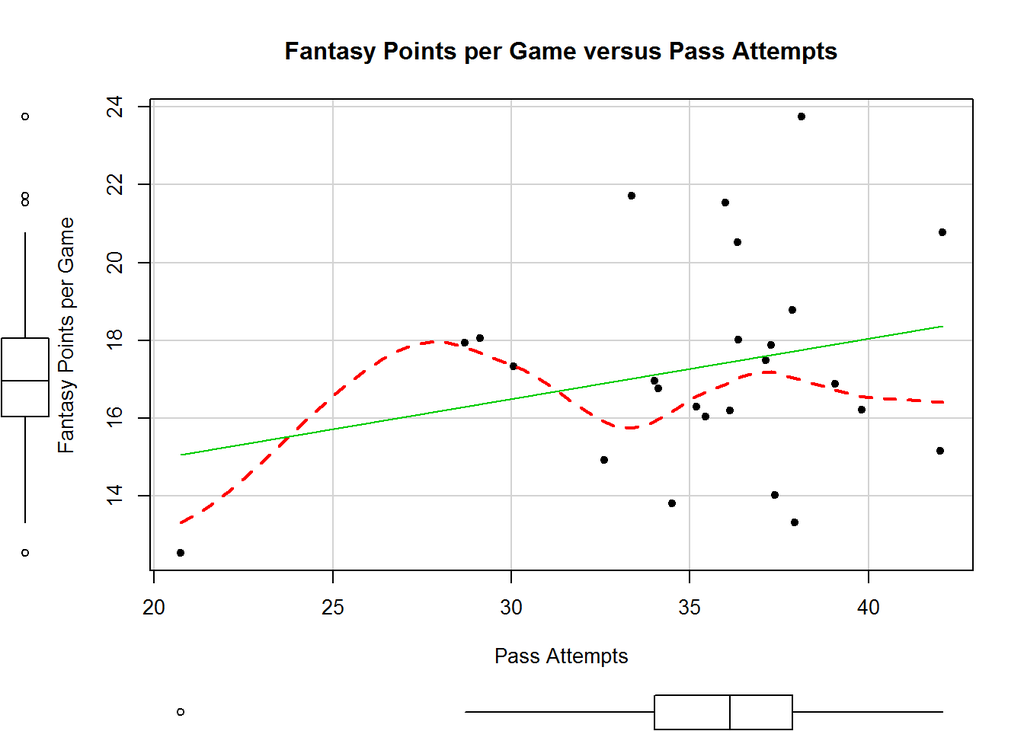

```r
scatterplot(Fantasy_PPG ~ Pass_Attempts_Per_Game, qb,
            spread=FALSE, smoother.args=list(lty=2), pch=19,
            main="Fantasy Points per Game versus Pass Attempts",
            xlab="Pass Attempts",
            ylab="Fantasy Points per Game")
```

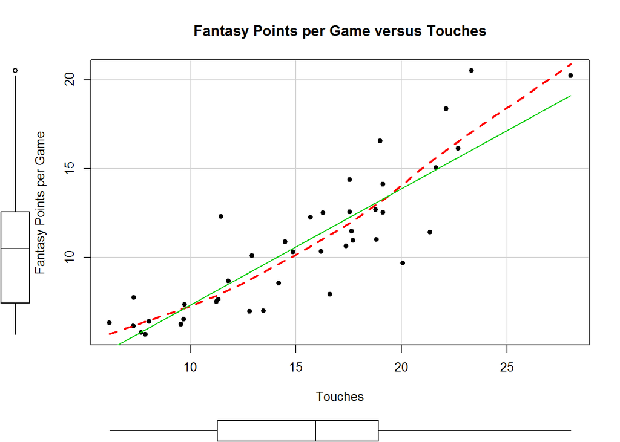

```r
scatterplot(Fantasy_PPG ~ Touches_Per_Game, rb,
            spread=FALSE, smoother.args=list(lty=2), pch=19,
            main="Fantasy Points per Game versus Touches",
            xlab="Touches",
            ylab="Fantasy Points per Game")
```

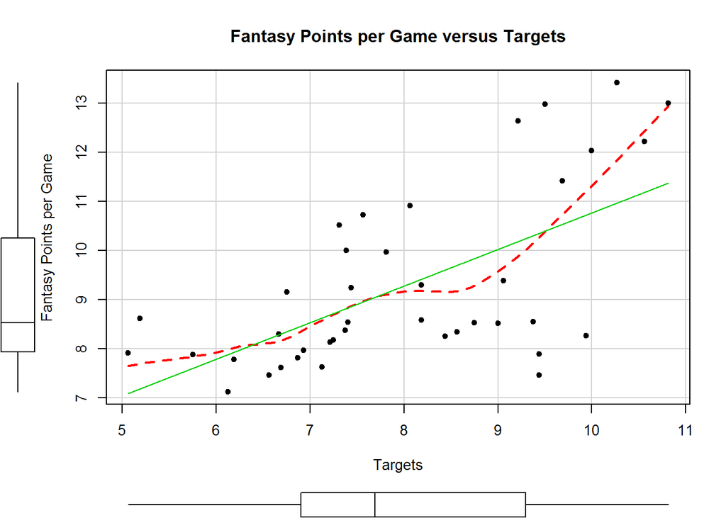

```r
scatterplot(Fantasy_PPG ~ Targets_Per_Game, wr,
            spread=FALSE, smoother.args=list(lty=2), pch=19,
            main="Fantasy Points per Game versus Targets",
            xlab="Targets",
            ylab="Fantasy Points per Game")
```

##### RB

```r
fit_rb_p1 <- lm(Fantasy_PPG ~ I(Touches_Per_Game^2), rb)
summary(fit_rb_p1)
```

```
##
## Call:
## lm(formula = Fantasy_PPG ~ I(Touches_Per_Game^2), data = rb)
##
## Residuals:
##    Min     1Q Median     3Q    Max
## -4.068 -0.946 -0.283  1.125  4.227
##
## Coefficients:
##                       Estimate Std. Error t value Pr(>|t|)
## (Intercept)            5.33617    0.54859    9.73  7.3e-12 ***
## I(Touches_Per_Game^2)  0.02095    0.00179   11.68  3.9e-14 ***
## ---
## Signif. codes:  0 '***' 0.001 '**' 0.01 '*' 0.05 '.' 0.1 ' ' 1
##
## Residual standard error: 1.86 on 38 degrees of freedom
## Multiple R-squared:  0.782,  Adjusted R-squared:  0.776
## F-statistic:  136 on 1 and 38 DF,  p-value: 3.89e-14
```

```r
fit_rb_p2 <- lm(Fantasy_PPG ~ Touches_Per_Game + I(Touches_Per_Game^2), rb)
summary(fit_rb_p2)
```

```
##
## Call:
## lm(formula = Fantasy_PPG ~ Touches_Per_Game + I(Touches_Per_Game^2),
##     data = rb)
##
## Residuals:
##    Min     1Q Median     3Q    Max
## -4.100 -0.948 -0.165  1.071  4.211
##
## Coefficients:
##                       Estimate Std. Error t value Pr(>|t|)
## (Intercept)             4.7084     2.2320    2.11    0.042 *
## Touches_Per_Game        0.0872     0.3004    0.29    0.773
## I(Touches_Per_Game^2)   0.0182     0.0095    1.92    0.063 .
## ---
## Signif. codes:  0 '***' 0.001 '**' 0.01 '*' 0.05 '.' 0.1 ' ' 1
##
## Residual standard error: 1.88 on 37 degrees of freedom
## Multiple R-squared:  0.783,  Adjusted R-squared:  0.771
## F-statistic: 66.6 on 2 and 37 DF,  p-value: 5.53e-13
```

##### WR

```r
fit_wr_p1 <- lm(Fantasy_PPG ~ I(Targets_Per_Game^2), wr)
summary(fit_wr_p1)
```

```
##
## Call:
## lm(formula = Fantasy_PPG ~ I(Targets_Per_Game^2), data = wr)
##
## Residuals:
##    Min     1Q Median     3Q    Max
## -2.916 -0.759 -0.186  0.985  2.546
##
## Coefficients:
##                       Estimate Std. Error t value Pr(>|t|)
## (Intercept)            6.13188    0.65017    9.43  1.7e-11 ***
## I(Targets_Per_Game^2)  0.04768    0.00931    5.12  9.0e-06 ***
## ---
## Signif. codes:  0 '***' 0.001 '**' 0.01 '*' 0.05 '.' 0.1 ' ' 1
##
## Residual standard error: 1.38 on 38 degrees of freedom
## Multiple R-squared:  0.409,  Adjusted R-squared:  0.393
## F-statistic: 26.3 on 1 and 38 DF,  p-value: 9.01e-06
```

```r
fit_wr_p2 <- lm(Fantasy_PPG ~ Targets_Per_Game + I(Targets_Per_Game^2), wr)
summary(fit_wr_p2)
```

```
##
## Call:
## lm(formula = Fantasy_PPG ~ Targets_Per_Game + I(Targets_Per_Game^2),
##     data = wr)
##
## Residuals:
##    Min     1Q Median     3Q    Max
## -2.876 -0.754 -0.248  0.801  2.566
##
## Coefficients:
##                       Estimate Std. Error t value Pr(>|t|)
## (Intercept)            13.6581     5.9520    2.29    0.028 *
## Targets_Per_Game       -1.9227     1.5116   -1.27    0.211
## I(Targets_Per_Game^2)   0.1665     0.0938    1.77    0.084 .
## ---
## Signif. codes:  0 '***' 0.001 '**' 0.01 '*' 0.05 '.' 0.1 ' ' 1
##
## Residual standard error: 1.37 on 37 degrees of freedom
## Multiple R-squared:  0.433,  Adjusted R-squared:  0.403
## F-statistic: 14.2 on 2 and 37 DF,  p-value: 2.73e-05
```

#### Multiple Linear Regression

##### QB

```r
fit_qb_ml1 <- lm(Fantasy_PPG ~ Pass_Attempts_Per_Game + Pass_TD_Int_Ratio + Rush_Yards_Per_Game + Rush_Attempts_Per_Game, qb)
summary(fit_qb_ml1)
```

```
##
## Call:
## lm(formula = Fantasy_PPG ~ Pass_Attempts_Per_Game + Pass_TD_Int_Ratio +
##     Rush_Yards_Per_Game + Rush_Attempts_Per_Game, data = qb)
##
## Residuals:
##    Min     1Q Median     3Q    Max
## -3.438 -1.472 -0.136  0.987  4.354
##
## Coefficients:
##                        Estimate Std. Error t value Pr(>|t|)
## (Intercept)              -0.830      4.838   -0.17  0.86551
## Pass_Attempts_Per_Game    0.405      0.120    3.38  0.00300 **
## Pass_TD_Int_Ratio         0.651      0.163    3.99  0.00072 ***
## Rush_Yards_Per_Game       0.116      0.111    1.04  0.30922
## Rush_Attempts_Per_Game    0.131      0.720    0.18  0.85752
## ---
## Signif. codes:  0 '***' 0.001 '**' 0.01 '*' 0.05 '.' 0.1 ' ' 1
##
## Residual standard error: 2.07 on 20 degrees of freedom
## Multiple R-squared:  0.533,  Adjusted R-squared:  0.439
## F-statistic:  5.7 on 4 and 20 DF,  p-value: 0.00315
```

```r
fit_qb_ml2 <- lm(Fantasy_PPG ~ Pass_Attempts_Per_Game + Pass_TD_Int_Ratio, qb)
summary(fit_qb_ml2)
```

```
##
## Call:
## lm(formula = Fantasy_PPG ~ Pass_Attempts_Per_Game + Pass_TD_Int_Ratio,
##     data = qb)
##
## Residuals:
##    Min     1Q Median     3Q    Max
## -3.843 -1.324 -0.246  1.288  4.318
##
## Coefficients:
##                        Estimate Std. Error t value Pr(>|t|)
## (Intercept)               7.874      3.830    2.06   0.0519 .
## Pass_Attempts_Per_Game    0.215      0.104    2.07   0.0503 .
## Pass_TD_Int_Ratio         0.586      0.178    3.30   0.0033 **
## ---
## Signif. codes:  0 '***' 0.001 '**' 0.01 '*' 0.05 '.' 0.1 ' ' 1
##
## Residual standard error: 2.28 on 22 degrees of freedom
## Multiple R-squared:  0.375,  Adjusted R-squared:  0.318
## F-statistic:  6.6 on 2 and 22 DF,  p-value: 0.0057
```

##### RB

```r
fit_rb_ml1 <- lm(Fantasy_PPG ~ Rush_Attempts_Per_Game + Rush_Yards_Per_Attempt + Touches_Per_Game + I(Touches_Per_Game^2) + Targets_Per_Game + Reception_Percent, rb)
summary(fit_rb_ml1)
```

```
##
## Call:
## lm(formula = Fantasy_PPG ~ Rush_Attempts_Per_Game + Rush_Yards_Per_Attempt +
##     Touches_Per_Game + I(Touches_Per_Game^2) + Targets_Per_Game +
##     Reception_Percent, data = rb)
##
## Residuals:
##    Min     1Q Median     3Q    Max
## -2.762 -0.787 -0.107  0.924  4.201
##
## Coefficients:
##                         Estimate Std. Error t value Pr(>|t|)
## (Intercept)            -1.58e+01   5.56e+00   -2.84  0.00769 **
## Rush_Attempts_Per_Game  4.20e+00   1.96e+00    2.14  0.03964 *
## Rush_Yards_Per_Attempt  1.60e+00   3.90e-01    4.09  0.00026 ***
## Touches_Per_Game       -3.53e+00   1.93e+00   -1.83  0.07665 .
## I(Touches_Per_Game^2)   2.98e-04   9.21e-03    0.03  0.97440
## Targets_Per_Game        3.39e+00   1.50e+00    2.26  0.03086 *
## Reception_Percent       1.12e+01   5.17e+00    2.16  0.03830 *
## ---
## Signif. codes:  0 '***' 0.001 '**' 0.01 '*' 0.05 '.' 0.1 ' ' 1
##
## Residual standard error: 1.54 on 33 degrees of freedom
## Multiple R-squared:  0.869,  Adjusted R-squared:  0.846
## F-statistic: 36.6 on 6 and 33 DF,  p-value: 3.22e-13
```

```r
fit_rb_ml2 <- lm(Fantasy_PPG ~ Rush_Attempts_Per_Game + Rush_Yards_Per_Attempt + Touches_Per_Game + Targets_Per_Game + Reception_Percent, rb)
summary(fit_rb_ml2)
```

```
##
## Call:
## lm(formula = Fantasy_PPG ~ Rush_Attempts_Per_Game + Rush_Yards_Per_Attempt +
##     Touches_Per_Game + Targets_Per_Game + Reception_Percent,
##     data = rb)
##
## Residuals:
##    Min     1Q Median     3Q    Max
## -2.757 -0.792 -0.091  0.928  4.198
##
## Coefficients:
##                        Estimate Std. Error t value Pr(>|t|)
## (Intercept)              -15.88       4.37   -3.64  0.00091 ***
## Rush_Attempts_Per_Game     4.21       1.91    2.21  0.03401 *
## Rush_Yards_Per_Attempt     1.60       0.37    4.32  0.00013 ***
## Touches_Per_Game          -3.53       1.90   -1.86  0.07213 .
## Targets_Per_Game           3.40       1.45    2.35  0.02479 *
## Reception_Percent         11.20       5.01    2.23  0.03213 *
## ---
## Signif. codes:  0 '***' 0.001 '**' 0.01 '*' 0.05 '.' 0.1 ' ' 1
##
## Residual standard error: 1.52 on 34 degrees of freedom
## Multiple R-squared:  0.869,  Adjusted R-squared:  0.85
## F-statistic: 45.3 on 5 and 34 DF,  p-value: 4.5e-14
```

##### WR

```r
fit_wr_ml1 <- lm(Fantasy_PPG ~ Targets_Per_Game + I(Targets_Per_Game^2) + Reception_Percent + Yards_Per_Target + Yards_Per_Reception, wr)
summary(fit_wr_ml1)
```

```
##
## Call:
## lm(formula = Fantasy_PPG ~ Targets_Per_Game + I(Targets_Per_Game^2) +
##     Reception_Percent + Yards_Per_Target + Yards_Per_Reception,
##     data = wr)
##
## Residuals:
##    Min     1Q Median     3Q    Max
## -1.964 -0.818 -0.145  0.549  2.367
##
## Coefficients:
##                       Estimate Std. Error t value Pr(>|t|)
## (Intercept)            -2.4487    14.7122   -0.17     0.87
## Targets_Per_Game       -1.8630     1.2686   -1.47     0.15
## I(Targets_Per_Game^2)   0.1758     0.0777    2.26     0.03 *
## Reception_Percent      13.5558    19.0573    0.71     0.48
## Yards_Per_Target       -0.1653     1.4347   -0.12     0.91
## Yards_Per_Reception     0.5874     0.8932    0.66     0.52
## ---
## Signif. codes:  0 '***' 0.001 '**' 0.01 '*' 0.05 '.' 0.1 ' ' 1
##
## Residual standard error: 1.09 on 34 degrees of freedom
## Multiple R-squared:  0.673,  Adjusted R-squared:  0.625
## F-statistic:   14 on 5 and 34 DF,  p-value: 1.87e-07
```

```r
fit_wr_ml2 <- lm(Fantasy_PPG ~ Targets_Per_Game + I(Targets_Per_Game^2) + Reception_Percent + Yards_Per_Reception, wr)
summary(fit_wr_ml2)
```

```
##
## Call:
## lm(formula = Fantasy_PPG ~ Targets_Per_Game + I(Targets_Per_Game^2) +
##     Reception_Percent + Yards_Per_Reception, data = wr)
##
## Residuals:
##    Min     1Q Median     3Q    Max
## -1.967 -0.816 -0.158  0.562  2.366
##
## Coefficients:
##                       Estimate Std. Error t value Pr(>|t|)
## (Intercept)            -0.8804     5.4973   -0.16  0.87369
## Targets_Per_Game       -1.9112     1.1806   -1.62  0.11448
## I(Targets_Per_Game^2)   0.1784     0.0733    2.43  0.02025 *
## Reception_Percent      11.3849     2.7935    4.08  0.00025 ***
## Yards_Per_Reception     0.4852     0.1024    4.74  3.5e-05 ***
## ---
## Signif. codes:  0 '***' 0.001 '**' 0.01 '*' 0.05 '.' 0.1 ' ' 1
##
## Residual standard error: 1.07 on 35 degrees of freedom
## Multiple R-squared:  0.673,  Adjusted R-squared:  0.636
## F-statistic:   18 on 4 and 35 DF,  p-value: 4.08e-08
```

```r
fit_wr_ml3 <- lm(Fantasy_PPG ~ I(Targets_Per_Game^2) + Reception_Percent + Yards_Per_Reception, wr)
summary(fit_wr_ml3)
```

```
##
## Call:
## lm(formula = Fantasy_PPG ~ I(Targets_Per_Game^2) + Reception_Percent +
##     Yards_Per_Reception, data = wr)
##
## Residuals:
##    Min     1Q Median     3Q    Max
## -1.819 -0.896 -0.152  0.538  2.346
##
## Coefficients:
##                       Estimate Std. Error t value Pr(>|t|)
## (Intercept)           -8.37215    3.03269   -2.76  0.00902 **
## I(Targets_Per_Game^2)  0.06032    0.00782    7.71  3.9e-09 ***
## Reception_Percent     11.39699    2.85572    3.99  0.00031 ***
## Yards_Per_Reception    0.48543    0.10465    4.64  4.5e-05 ***
## ---
## Signif. codes:  0 '***' 0.001 '**' 0.01 '*' 0.05 '.' 0.1 ' ' 1
##
## Residual standard error: 1.1 on 36 degrees of freedom
## Multiple R-squared:  0.649,  Adjusted R-squared:  0.619
## F-statistic: 22.1 on 3 and 36 DF,  p-value: 2.67e-08
```

##### TE

```r
fit_te_ml1 <- lm(Fantasy_PPG ~ Targets_Per_Game + Reception_Percent + Yards_Per_Target + Yards_Per_Reception, te)
summary(fit_te_ml1)
```

```
##
## Call:
## lm(formula = Fantasy_PPG ~ Targets_Per_Game + Reception_Percent +
##     Yards_Per_Target + Yards_Per_Reception, data = te)
##
## Residuals:
##     Min      1Q  Median      3Q     Max
## -1.5606 -0.6606  0.0512  0.6813  1.6340
##
## Coefficients:
##                     Estimate Std. Error t value Pr(>|t|)
## (Intercept)            3.894     11.214    0.35     0.73
## Targets_Per_Game       0.752      0.148    5.07  5.9e-05 ***
## Reception_Percent     -9.522     16.502   -0.58     0.57
## Yards_Per_Target       1.112      1.334    0.83     0.41
## Yards_Per_Reception   -0.347      0.883   -0.39     0.70
## ---
## Signif. codes:  0 '***' 0.001 '**' 0.01 '*' 0.05 '.' 0.1 ' ' 1
##
## Residual standard error: 0.926 on 20 degrees of freedom
## Multiple R-squared:  0.643,  Adjusted R-squared:  0.572
## F-statistic: 9.02 on 4 and 20 DF,  p-value: 0.000247
```

```r
fit_te_ml2 <- lm(Fantasy_PPG ~ Targets_Per_Game + Yards_Per_Target, te)
summary(fit_te_ml2)
```

```
##
## Call:
## lm(formula = Fantasy_PPG ~ Targets_Per_Game + Yards_Per_Target,
##     data = te)
##
## Residuals:
##     Min      1Q  Median      3Q     Max
## -1.6730 -0.4446 -0.0132  0.7090  1.8189
##
## Coefficients:
##                  Estimate Std. Error t value Pr(>|t|)
## (Intercept)        -2.334      1.523   -1.53     0.14
## Targets_Per_Game    0.751      0.145    5.20  3.3e-05 ***
## Yards_Per_Target    0.570      0.118    4.82  8.1e-05 ***
## ---
## Signif. codes:  0 '***' 0.001 '**' 0.01 '*' 0.05 '.' 0.1 ' ' 1
##
## Residual standard error: 0.909 on 22 degrees of freedom
## Multiple R-squared:  0.622,  Adjusted R-squared:  0.587
## F-statistic: 18.1 on 2 and 22 DF,  p-value: 2.27e-05
```

### Task 2

#### Diagnostic: multiple diagnostics (base R plot())

##### QB

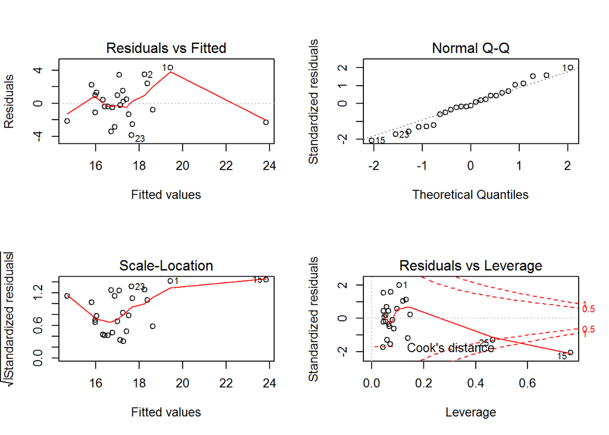

```r
opar <- par(no.readonly=TRUE)
fit_qb <- lm(Fantasy_PPG ~ Pass_Attempts_Per_Game + Pass_TD_Int_Ratio, qb)
par(mfrow=c(2,2))
plot(fit_qb)
```

```r
par(opar)
```

##### RB

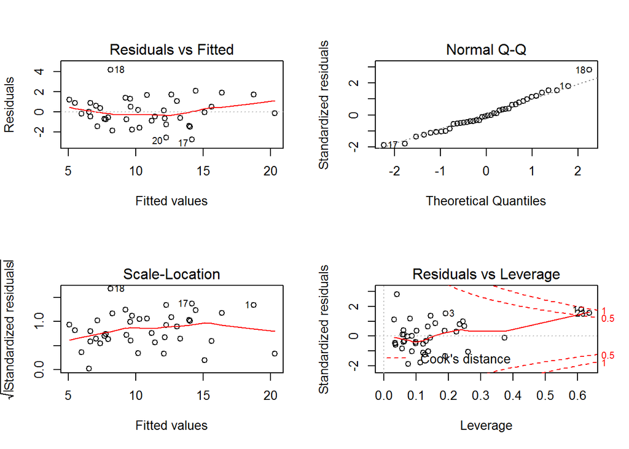

```r
opar <- par(no.readonly=TRUE)
fit_rb <- lm(Fantasy_PPG ~ Rush_Attempts_Per_Game + Rush_Yards_Per_Attempt + Touches_Per_Game + Targets_Per_Game + Reception_Percent, rb)
par(mfrow=c(2,2))
plot(fit_rb)
```

```r
par(opar)
```

##### WR

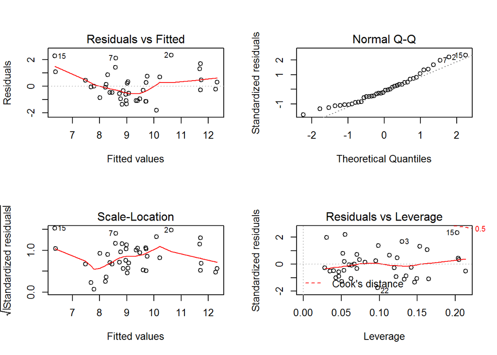

```r
opar <- par(no.readonly=TRUE)
fit_wr <- lm(Fantasy_PPG ~ I(Targets_Per_Game^2) + Reception_Percent + Yards_Per_Reception, wr)
par(mfrow=c(2,2))
plot(fit_wr)
```

```r
par(opar)
```

##### TE

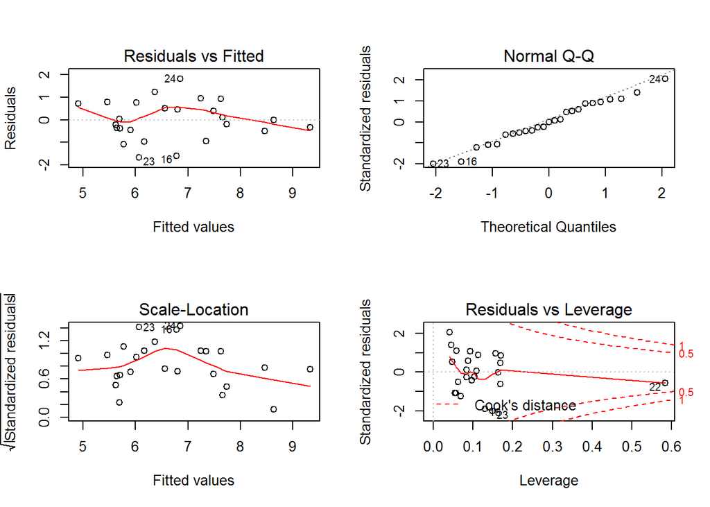

```r
opar <- par(no.readonly=TRUE)
fit_te <- lm(Fantasy_PPG ~ Targets_Per_Game + Yards_Per_Target, te)
par(mfrow=c(2,2))
plot(fit_te)
```

```r
par(opar)
```

#### Diagnostic: Residual values normally distributed with a mean of 0 (qqPlot) - meaning dependent variable is normally distributed

##### QB

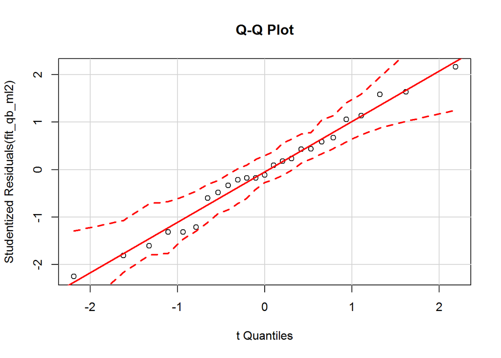

```r
qqPlot(fit_qb_ml2, labels=row.names(qb), id.method="identify",
       simulate=TRUE, main="Q-Q Plot")
```

##### RB

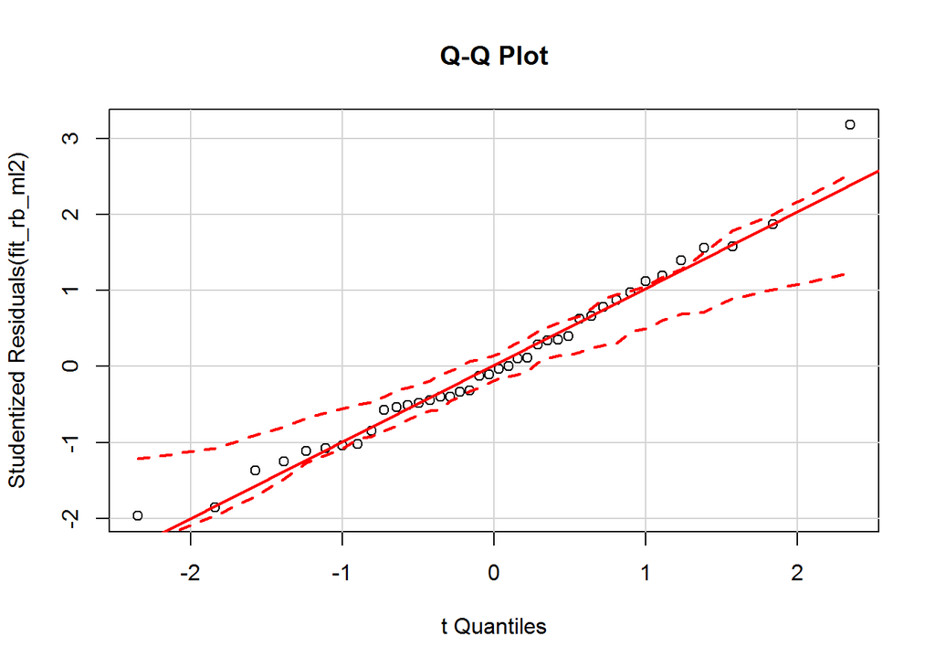

```r
qqPlot(fit_rb_ml2, labels=row.names(rb), id.method="identify",
       simulate=TRUE, main="Q-Q Plot")
```

##### WR

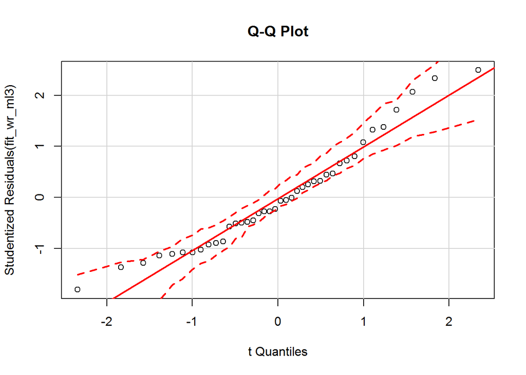

```r
qqPlot(fit_wr_ml3, labels=row.names(wr), id.method="identify",
       simulate=TRUE, main="Q-Q Plot")
```

##### TE

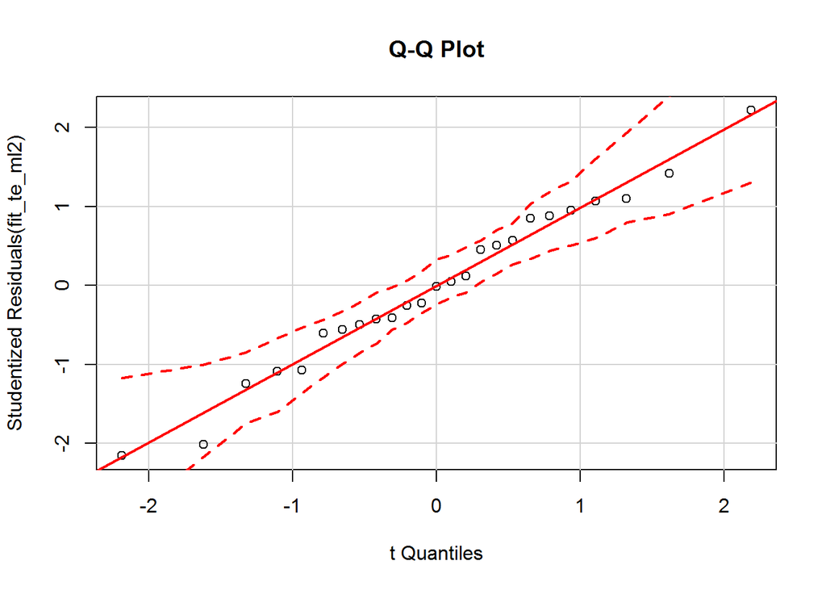

```r
qqPlot(fit_te_ml2, labels=row.names(te), id.method="identify",
       simulate=TRUE, main="Q-Q Plot")
```

#### Diagnostic: Homoscedasticity

##### QB

```r
ncvTest(fit_qb_ml2)
```

```
## Non-constant Variance Score Test
## Variance formula: ~ fitted.values
## Chisquare = 1.29    Df = 1     p = 0.257
```

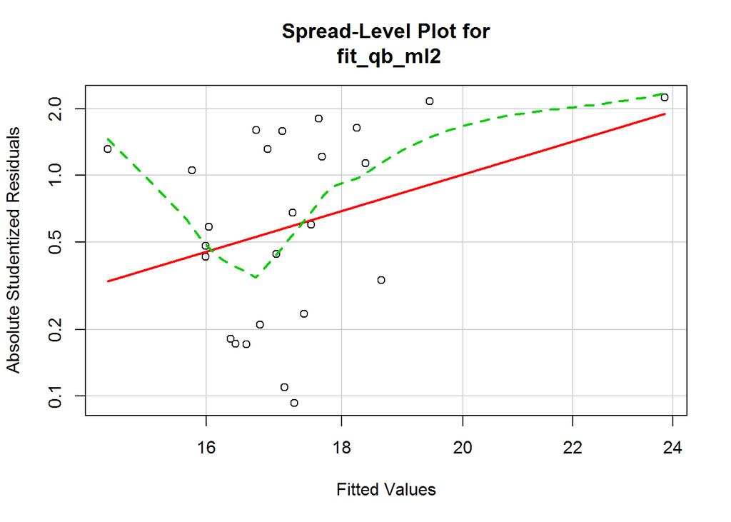

```
##
## Suggested power transformation:  -2.61
```

```r
spreadLevelPlot(fit_qb_ml2)
```

```r
gv_qb <- gvlma(fit_qb_ml2)
summary(gv_qb)
```

```
##
## Call:
## lm(formula = Fantasy_PPG ~ Pass_Attempts_Per_Game + Pass_TD_Int_Ratio,
##     data = qb)
##
## Residuals:
##    Min     1Q Median     3Q    Max
## -3.843 -1.324 -0.246  1.288  4.318
##
## Coefficients:
##                        Estimate Std. Error t value Pr(>|t|)
## (Intercept)               7.874      3.830    2.06   0.0519 .
## Pass_Attempts_Per_Game    0.215      0.104    2.07   0.0503 .
## Pass_TD_Int_Ratio         0.586      0.178    3.30   0.0033 **
## ---
## Signif. codes:  0 '***' 0.001 '**' 0.01 '*' 0.05 '.' 0.1 ' ' 1
##
## Residual standard error: 2.28 on 22 degrees of freedom
## Multiple R-squared:  0.375,  Adjusted R-squared:  0.318
## F-statistic:  6.6 on 2 and 22 DF,  p-value: 0.0057
##
##
## ASSESSMENT OF THE LINEAR MODEL ASSUMPTIONS
## USING THE GLOBAL TEST ON 4 DEGREES-OF-FREEDOM:
## Level of Significance =  0.05
##
## Call:
##  gvlma(x = fit_qb_ml2)
##
##                     Value p-value                   Decision
## Global Stat        4.6016  0.3307    Assumptions acceptable.
## Skewness           0.0753  0.7838    Assumptions acceptable.
## Kurtosis           0.4924  0.4828    Assumptions acceptable.
## Link Function      3.9020  0.0482 Assumptions NOT satisfied!
## Heteroscedasticity 0.1319  0.7164    Assumptions acceptable.
```

##### RB

```r
ncvTest(fit_rb_ml2)
```

```
## Non-constant Variance Score Test
## Variance formula: ~ fitted.values
## Chisquare = 0.211    Df = 1     p = 0.646
```

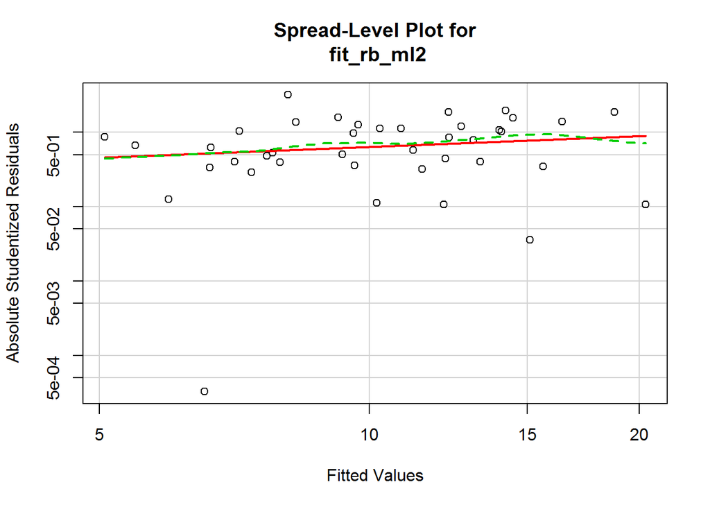

```
##
## Suggested power transformation:  0.508
```

```r
spreadLevelPlot(fit_rb_ml2)
```

```r
gv_rb <- gvlma(fit_rb_ml2)
summary(gv_rb)
```

```
##
## Call:
## lm(formula = Fantasy_PPG ~ Rush_Attempts_Per_Game + Rush_Yards_Per_Attempt +
##     Touches_Per_Game + Targets_Per_Game + Reception_Percent,
##     data = rb)
##
## Residuals:
##    Min     1Q Median     3Q    Max
## -2.757 -0.792 -0.091  0.928  4.198
##
## Coefficients:
##                        Estimate Std. Error t value Pr(>|t|)
## (Intercept)              -15.88       4.37   -3.64  0.00091 ***
## Rush_Attempts_Per_Game     4.21       1.91    2.21  0.03401 *
## Rush_Yards_Per_Attempt     1.60       0.37    4.32  0.00013 ***
## Touches_Per_Game          -3.53       1.90   -1.86  0.07213 .
## Targets_Per_Game           3.40       1.45    2.35  0.02479 *
## Reception_Percent         11.20       5.01    2.23  0.03213 *
## ---
## Signif. codes:  0 '***' 0.001 '**' 0.01 '*' 0.05 '.' 0.1 ' ' 1
##
## Residual standard error: 1.52 on 34 degrees of freedom
## Multiple R-squared:  0.869,  Adjusted R-squared:  0.85
## F-statistic: 45.3 on 5 and 34 DF,  p-value: 4.5e-14
##
##
## ASSESSMENT OF THE LINEAR MODEL ASSUMPTIONS
## USING THE GLOBAL TEST ON 4 DEGREES-OF-FREEDOM:
## Level of Significance =  0.05
##
## Call:
##  gvlma(x = fit_rb_ml2)
##
##                    Value p-value                Decision
## Global Stat        4.881   0.300 Assumptions acceptable.
## Skewness           1.250   0.264 Assumptions acceptable.
## Kurtosis           0.305   0.581 Assumptions acceptable.
## Link Function      2.433   0.119 Assumptions acceptable.
## Heteroscedasticity 0.893   0.345 Assumptions acceptable.
```

##### WR

```r
ncvTest(fit_wr_ml3)
```

```
## Non-constant Variance Score Test
## Variance formula: ~ fitted.values
## Chisquare = 0.0429    Df = 1     p = 0.836
```

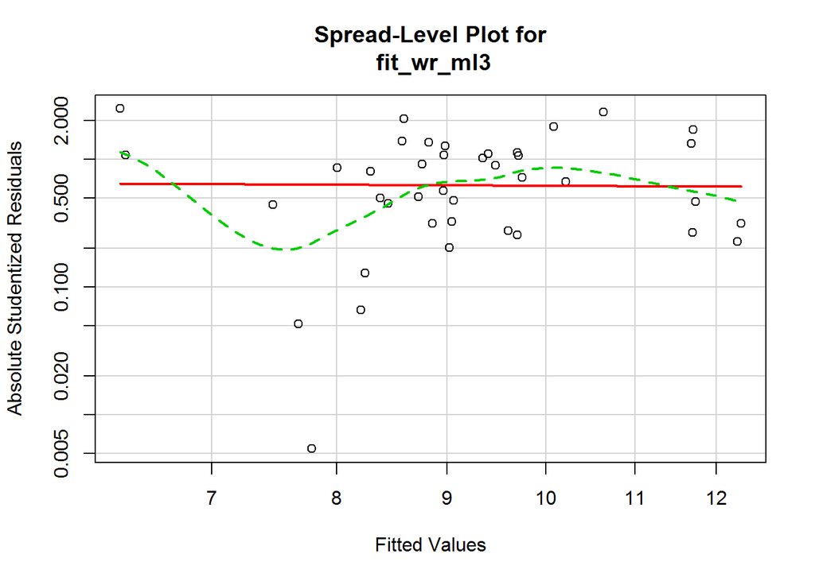

```
##
## Suggested power transformation:  1.09
```

```r
spreadLevelPlot(fit_wr_ml3)
```

```r
gv_wr <- gvlma(fit_wr_ml3)
summary(gv_wr)
```

```
##
## Call:
## lm(formula = Fantasy_PPG ~ I(Targets_Per_Game^2) + Reception_Percent +
##     Yards_Per_Reception, data = wr)
##
## Residuals:
##    Min     1Q Median     3Q    Max
## -1.819 -0.896 -0.152  0.538  2.346
##
## Coefficients:
##                       Estimate Std. Error t value Pr(>|t|)
## (Intercept)           -8.37215    3.03269   -2.76  0.00902 **
## I(Targets_Per_Game^2)  0.06032    0.00782    7.71  3.9e-09 ***
## Reception_Percent     11.39699    2.85572    3.99  0.00031 ***
## Yards_Per_Reception    0.48543    0.10465    4.64  4.5e-05 ***
## ---
## Signif. codes:  0 '***' 0.001 '**' 0.01 '*' 0.05 '.' 0.1 ' ' 1
##
## Residual standard error: 1.1 on 36 degrees of freedom
## Multiple R-squared:  0.649,  Adjusted R-squared:  0.619
## F-statistic: 22.1 on 3 and 36 DF,  p-value: 2.67e-08
##
##
## ASSESSMENT OF THE LINEAR MODEL ASSUMPTIONS
## USING THE GLOBAL TEST ON 4 DEGREES-OF-FREEDOM:
## Level of Significance =  0.05
##
## Call:
##  gvlma(x = fit_wr_ml3)
##
##                     Value p-value                   Decision
## Global Stat        13.416 0.00941 Assumptions NOT satisfied!
## Skewness            2.299 0.12944    Assumptions acceptable.
## Kurtosis            0.193 0.66033    Assumptions acceptable.
## Link Function       8.637 0.00329 Assumptions NOT satisfied!
## Heteroscedasticity  2.287 0.13049    Assumptions acceptable.
```

##### TE

```r
ncvTest(fit_te_ml2)
```

```
## Non-constant Variance Score Test
## Variance formula: ~ fitted.values
## Chisquare = 0.32    Df = 1     p = 0.571
```

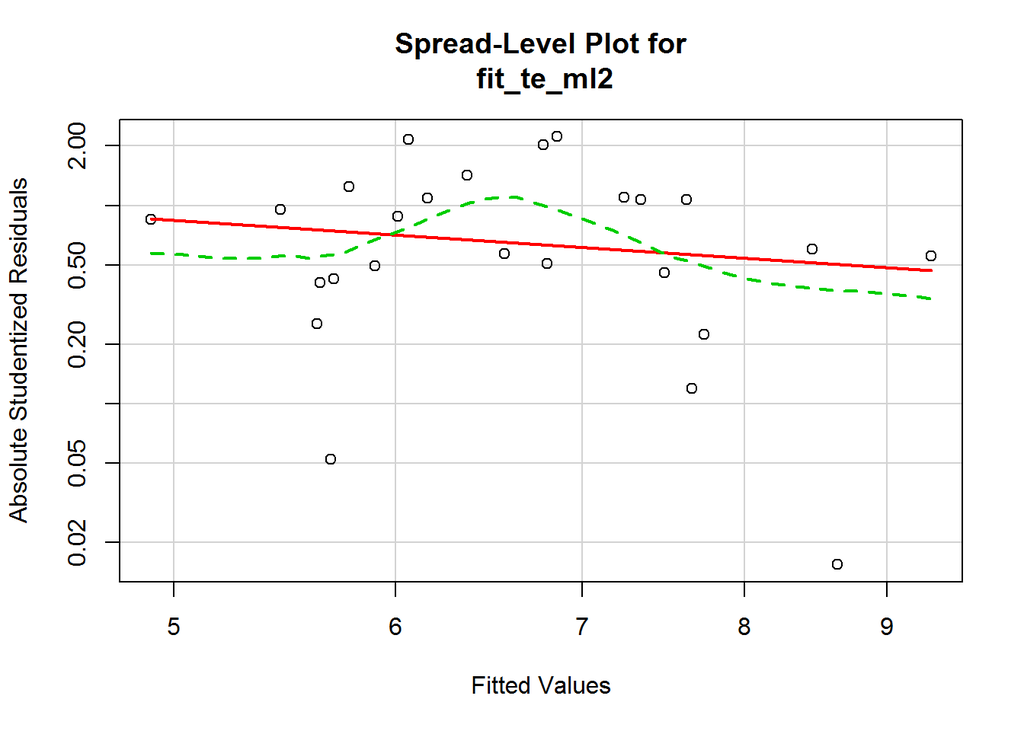

```
##
## Suggested power transformation:  1.93
```

```r
spreadLevelPlot(fit_te_ml2)
```

```r
gv_te <- gvlma(fit_te_ml2)
summary(gv_te)
```

```
##
## Call:
## lm(formula = Fantasy_PPG ~ Targets_Per_Game + Yards_Per_Target,
##     data = te)
##
## Residuals:
##     Min      1Q  Median      3Q     Max
## -1.6730 -0.4446 -0.0132  0.7090  1.8189
##
## Coefficients:
##                  Estimate Std. Error t value Pr(>|t|)
## (Intercept)        -2.334      1.523   -1.53     0.14
## Targets_Per_Game    0.751      0.145    5.20  3.3e-05 ***
## Yards_Per_Target    0.570      0.118    4.82  8.1e-05 ***
## ---
## Signif. codes:  0 '***' 0.001 '**' 0.01 '*' 0.05 '.' 0.1 ' ' 1
##
## Residual standard error: 0.909 on 22 degrees of freedom
## Multiple R-squared:  0.622,  Adjusted R-squared:  0.587
## F-statistic: 18.1 on 2 and 22 DF,  p-value: 2.27e-05
##
##
## ASSESSMENT OF THE LINEAR MODEL ASSUMPTIONS
## USING THE GLOBAL TEST ON 4 DEGREES-OF-FREEDOM:
## Level of Significance =  0.05
##
## Call:
##  gvlma(x = fit_te_ml2)
##
##                     Value p-value                Decision
## Global Stat        2.9905   0.559 Assumptions acceptable.
## Skewness           0.0157   0.900 Assumptions acceptable.
## Kurtosis           0.2301   0.631 Assumptions acceptable.
## Link Function      0.2155   0.643 Assumptions acceptable.
## Heteroscedasticity 2.5293   0.112 Assumptions acceptable.
```

#### Diagnostic: No perfect linear relationship between explanatory variables

##### QB

```r
vif(fit_qb_ml2)
```

```
## Pass_Attempts_Per_Game      Pass_TD_Int_Ratio
##                   1.03                   1.03
```

```r
sqrt(vif(fit_qb_ml2)) > 2
```

```
## Pass_Attempts_Per_Game      Pass_TD_Int_Ratio
##                  FALSE                  FALSE
```

##### RB

```r
vif(fit_rb_ml2)
```

```
## Rush_Attempts_Per_Game Rush_Yards_Per_Attempt       Touches_Per_Game
##                1544.82                   1.09                1675.28
##       Targets_Per_Game      Reception_Percent
##                  97.30                   3.54
```

```r
sqrt(vif(fit_rb_ml2)) > 2
```

```
## Rush_Attempts_Per_Game Rush_Yards_Per_Attempt       Touches_Per_Game
##                   TRUE                  FALSE                   TRUE
##       Targets_Per_Game      Reception_Percent
##                   TRUE                  FALSE
```

##### WR

```r
vif(fit_wr_ml3)
```

```
## I(Targets_Per_Game^2)     Reception_Percent   Yards_Per_Reception
##                  1.13                  1.47                  1.45
```

```r
sqrt(vif(fit_wr_ml3)) > 2
```

```
## I(Targets_Per_Game^2)     Reception_Percent   Yards_Per_Reception
##                 FALSE                 FALSE                 FALSE
```

##### TE

```r
vif(fit_te_ml2)
```

```
## Targets_Per_Game Yards_Per_Target
##             1.18             1.18
```

```r
sqrt(vif(fit_te_ml2)) > 2
```

```
## Targets_Per_Game Yards_Per_Target
##            FALSE            FALSE
```

#### Diagnostic: Lack of significant outliers

##### QB

```r
outlierTest(fit_qb_ml2)
```

```
##
## No Studentized residuals with Bonferonni p < 0.05
## Largest |rstudent|:
##    rstudent unadjusted p-value Bonferonni p
## 15    -2.25             0.0353        0.884
```

##### RB

```r
outlierTest(fit_rb_ml2)
```

```
##
## No Studentized residuals with Bonferonni p < 0.05
## Largest |rstudent|:
##    rstudent unadjusted p-value Bonferonni p
## 18     3.18            0.00321        0.128
```

##### WR

```r
outlierTest(fit_wr_ml3)
```

```
##
## No Studentized residuals with Bonferonni p < 0.05
## Largest |rstudent|:
##    rstudent unadjusted p-value Bonferonni p
## 15     2.49             0.0177        0.707
```

##### TE

```r
outlierTest(fit_te_ml2)
```

```
##
## No Studentized residuals with Bonferonni p < 0.05
## Largest |rstudent|:
##    rstudent unadjusted p-value Bonferonni p
## 24     2.22             0.0377        0.943
```

#### Diagnostic: Lack of significant influential observations

##### QB

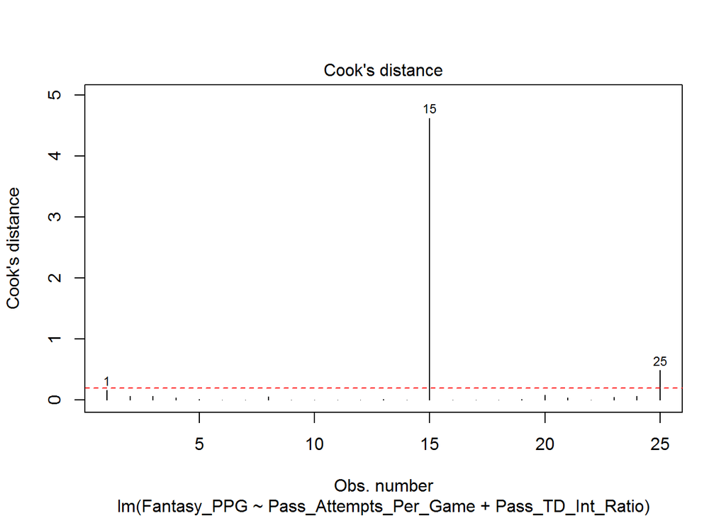

```r
cutoff_qb <- 4/(nrow(qb)-length(fit_qb_ml2$coefficients)-2)
plot(fit_qb_ml2, which=4, cook.levels=cutoff_qb)
abline(h=cutoff_qb, lty=2, col="red")
```

##### RB

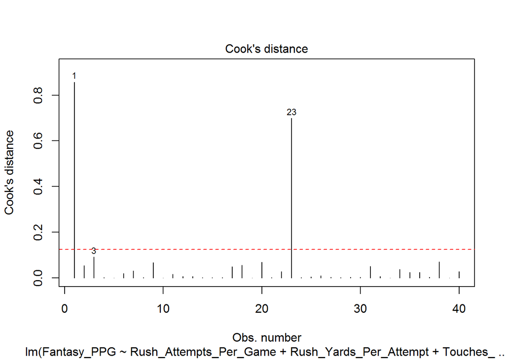

```r
cutoff_rb <- 4/(nrow(rb)-length(fit_rb_ml2$coefficients)-2)
plot(fit_rb_ml2, which=4, cook.levels=cutoff_rb)
abline(h=cutoff_rb, lty=2, col="red")
```

##### WR

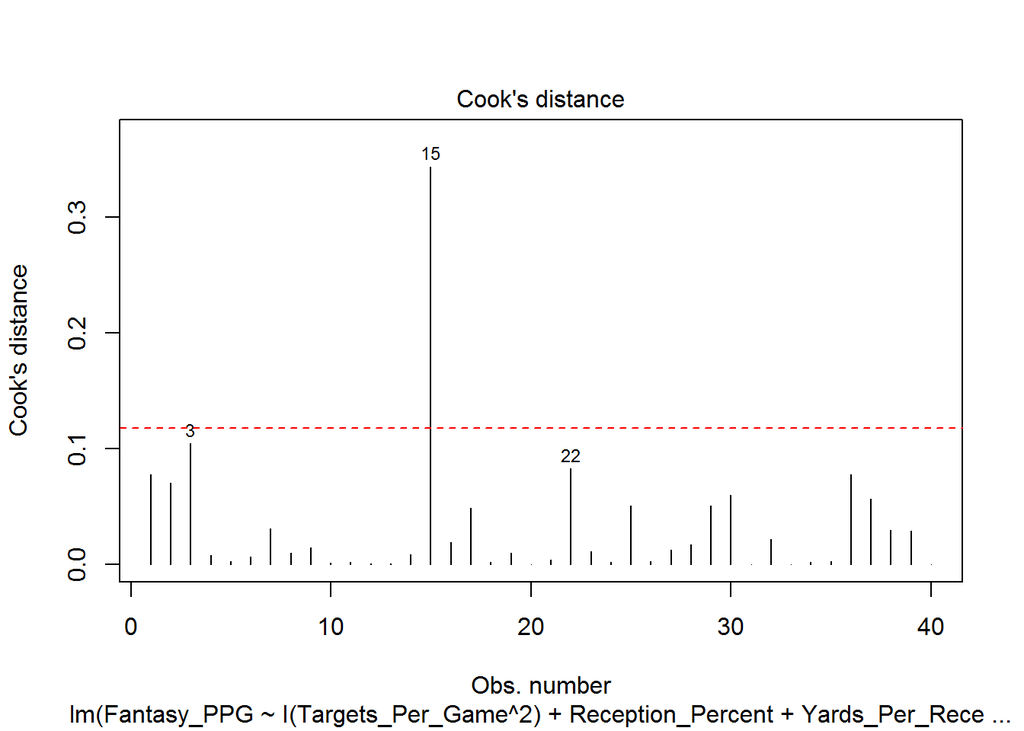

```r
cutoff_wr <- 4/(nrow(wr)-length(fit_wr_ml3$coefficients)-2)
plot(fit_wr_ml3, which=4, cook.levels=cutoff_wr)
abline(h=cutoff_wr, lty=2, col="red")
```

##### TE

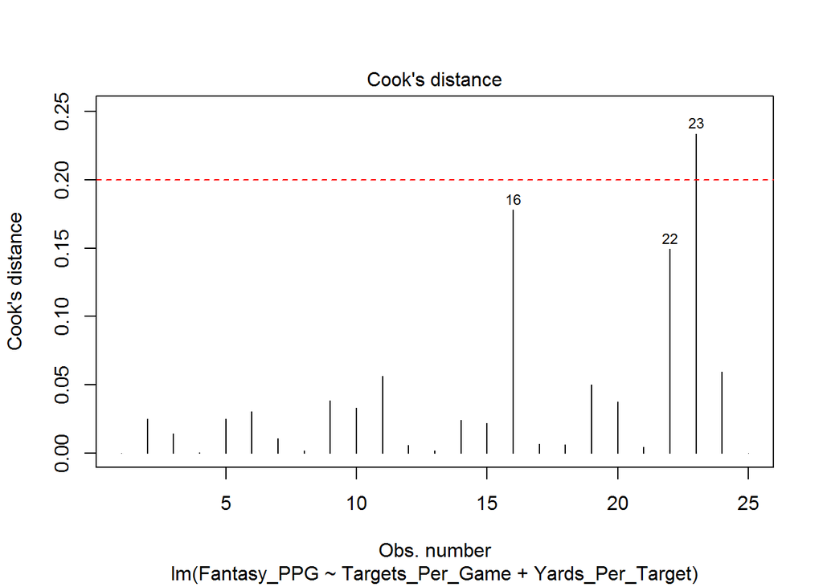

```r
cutoff_te <- 4/(nrow(te)-length(fit_te_ml2$coefficients)-2)
plot(fit_te_ml2, which=4, cook.levels=cutoff_te)
abline(h=cutoff_te, lty=2, col="red")
```